# PART 1

- What are the input text parameters?
- What are the labels? :
  - Gender
  - Age
  - Industry
  - Astrological Sign

###### MemoryError: Unable to allocate 468. MiB for an array with shape (204386, 300) and data type float64

```python
import pandas as pd
import numpy as np
import matplotlib.pyplot as plt
import seaborn as sns
%matplotlib inline
sns.set(color_codes = True)
```

```python
from nltk.tokenize import RegexpTokenizer
import re
from sklearn.model_selection import train_test_split
```

##### DATA EXPLORATION

```python
data = pd.read_csv('blogtext.csv')
```

```python
data.shape
```

```
(681284, 7)
```

```python
pd.options.display.max_colwidth = 200
data.head(5)
```

|  | id | gender | age | topic | sign | date | text |
| --- | --- | --- | --- | --- | --- | --- | --- |
| 0 | 2059027 | male | 15 | Student | Leo | 14,May,2004 | Info has been found (+/- 100 pages, and 4.5 MB of .pdf files) Now i have to wait untill our team leader has processed it and learns html. |
| 1 | 2059027 | male | 15 | Student | Leo | 13,May,2004 | These are the team members: Drewes van der Laag urlLink mail Ruiyu Xie urlLink mail Bryan Aaldering (me) urlLink mail |
| 2 | 2059027 | male | 15 | Student | Leo | 12,May,2004 | In het kader van kernfusie op aarde: MAAK JE EIGEN WATERSTOFBOM How to build an H-Bomb From: ascott@tartarus.uwa.edu.au (Andrew Scott) Newsgroups: rec.humor Subject: How To Build An ... |
| 3 | 2059027 | male | 15 | Student | Leo | 12,May,2004 | testing!!! testing!!! |
| 4 | 3581210 | male | 33 | InvestmentBanking | Aquarius | 11,June,2004 | Thanks to Yahoo!'s Toolbar I can now 'capture' the URLs of popups...which means now I can show you some cool links to Korean Pop (K-Pop) audio and video without the need to relate ins... |

Here, given the problem is typically a classification one. It shouldn't make any sense to predict date and id as it's does not describe any potentially important aspect of any text.

```python
data.drop(columns = ['id','date'], axis = 0, inplace = True)
data.head(5)
```

|  | gender | age | topic | sign | text |
| --- | --- | --- | --- | --- | --- |
| 0 | male | 15 | Student | Leo | Info has been found (+/- 100 pages, and 4.5 MB of .pdf files) Now i have to wait untill our team leader has processed it and learns html. |
| 1 | male | 15 | Student | Leo | These are the team members: Drewes van der Laag urlLink mail Ruiyu Xie urlLink mail Bryan Aaldering (me) urlLink mail |
| 2 | male | 15 | Student | Leo | In het kader van kernfusie op aarde: MAAK JE EIGEN WATERSTOFBOM How to build an H-Bomb From: ascott@tartarus.uwa.edu.au (Andrew Scott) Newsgroups: rec.humor Subject: How To Build An ... |
| 3 | male | 15 | Student | Leo | testing!!! testing!!! |
| 4 | male | 33 | InvestmentBanking | Aquarius | Thanks to Yahoo!'s Toolbar I can now 'capture' the URLs of popups...which means now I can show you some cool links to Korean Pop (K-Pop) audio and video without the need to relate ins... |

###### EXPLORING DATA STATISTICS

```python
data[['gender','age','topic','sign']].dtypes
```

```
gender    object
age        int64
topic     object
sign      object
dtype: object
```

```python
print(sorted(data['age'].unique()), ', data type: ',data['age'].dtype)
```

```
[13, 14, 15, 16, 17, 23, 24, 25, 26, 27, 33, 34, 35, 36, 37, 38, 39, 40, 41, 42, 43, 44, 45, 46, 47, 48] , data type:  int64
```

```python
data['age'] = ['10s' if ((type(i)==int)&(i in range(0,18))) else i for i in data['age'] ]
data['age'] = ['20s' if ((type(i)==int)&(i in range(23,28))) else i for i in data['age'] ]
data['age'] = ['30s' if ((type(i)==int)&(i in range(33,49))) else i for i in data['age'] ]
```

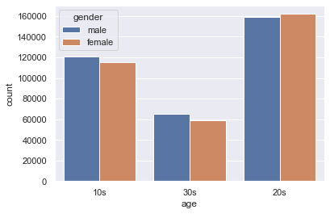

```python
sns.countplot(data['age'], hue =data['gender'])
```

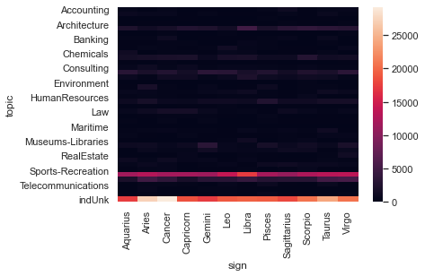

```python
cross_tab = pd.crosstab(data['topic'],data['sign'])
sns.heatmap(cross_tab)
```

Here it appears as though aries and cancer people have greater interesting in writing on "indUnk" than people with other zodiac signs.

However there's no particular pattern to learn from the above map since the two topics largely written on are Sports-Recreation and Unknown Industry by people of all signs. So all the said points makes it safe to discard Sign.

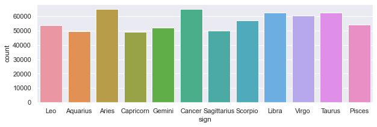

```python
plt.figure(figsize = (10,3))
sns.countplot(data['sign'])
```

But from above it's clear that people with signs Aries and Cancer are simply greater in number than people with other signs.

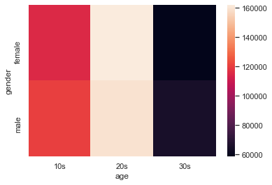

```python
cross_tab = pd.crosstab(data['gender'],data['age'])
sns.heatmap(cross_tab)
```

By and large, males and females write equally in numbers.

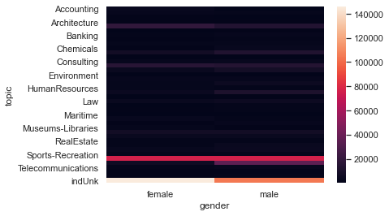

```python
cross_tab = pd.crosstab(data['topic'],data['gender'])
sns.heatmap(cross_tab)
```

Given, the counts of male and female bloggers are equal in numbers, it can be derived that females truly write more articles on indUnk that males. Males seem to write more on Telecommunications.

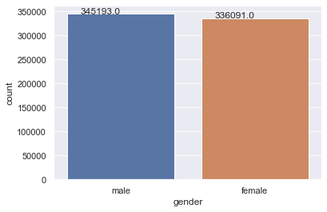

```python
ax = sns.countplot(data['gender'])

for p in ax.patches:
        ax.annotate('{:.1f}'.format(p.get_height()), (p.get_x()+0.1, p.get_height()+50))
```

###### Since the problem is typically a multilabel classification problem, it is widely advised that the labels are merged to unique collections of labels in the context of NLP problems at least.

```python
data['age'].unique()
```

```
array(['10s', '30s', '20s'], dtype=object)
```

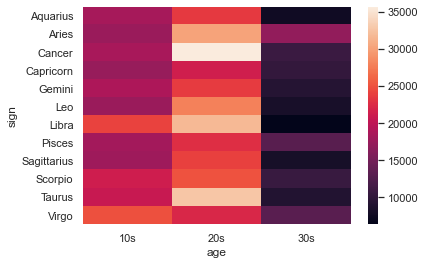

```python
cross_tab = pd.crosstab(data['sign'],data['age'])
sns.heatmap(cross_tab)
```

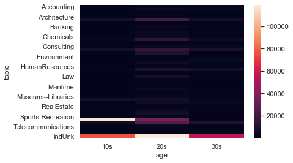

```python
cross_tab = pd.crosstab(data['topic'],data['age'])
sns.heatmap(cross_tab)
```

So from all the plots and maps, it's easily inferable that age tends to have a pattern against other variables. Hence to make the prediction output simpler, it should be a preemptive move to eliminate all that 'Age' follows a pattern with.

```python
data.drop(columns = ['gender','topic','sign'],axis = 0, inplace = True)
```

```python
data.head(5)
```

|  | age | text |
| --- | --- | --- |
| 0 | 10s | Info has been found (+/- 100 pages, and 4.5 MB of .pdf files) Now i have to wait untill our team leader has processed it and learns html. |
| 1 | 10s | These are the team members: Drewes van der Laag urlLink mail Ruiyu Xie urlLink mail Bryan Aaldering (me) urlLink mail |
| 2 | 10s | In het kader van kernfusie op aarde: MAAK JE EIGEN WATERSTOFBOM How to build an H-Bomb From: ascott@tartarus.uwa.edu.au (Andrew Scott) Newsgroups: rec.humor Subject: How To Build An ... |
| 3 | 10s | testing!!! testing!!! |
| 4 | 30s | Thanks to Yahoo!'s Toolbar I can now 'capture' the URLs of popups...which means now I can show you some cool links to Korean Pop (K-Pop) audio and video without the need to relate ins... |

###### Tokenization

```python
def tokenizer(comp):

    words = RegexpTokenizer('\w+').tokenize(comp)
    words = [re.sub(r'([xx]+)|([XX]+)|(\d+)', '', w).lower() for w in words]
    words = list(filter(lambda a: a != '', words))

    return words
```

###### Preparing Word Embeddings for Potential Words

```python
embeddings_index = {}
f = open('glove.6B.300d.txt',encoding="utf8")
embeddings_index['<unk>'] = 0
for line in f:
    values = line.split()
    word = values[0]
    coefs = np.asarray(values[1:], dtype='float32')
    embeddings_index[word] = coefs
f.close()
```

```python
word_data = list()
for words in data['text']:
    sentence = np.zeros(300)
    count = 0
    for w in tokenizer(words):
        try:
            sentence += embeddings_index[w]
            count += 1
        except KeyError:
            continue
    word_data.append(sentence / count)
```

Here, the word embedding for each word in each sentence in the dataset is normalized by the wordcount and append to form back the respective sentences in the embedded data array.

```python
from sklearn import preprocessing
le = preprocessing.LabelEncoder()
le.fit(data['age'])
data['target'] = le.transform(data['age'])
```

```python
data.head()
```

|  | age | text | target |
| --- | --- | --- | --- |
| 0 | 10s | Info has been found (+/- 100 pages, and 4.5 MB of .pdf files) Now i have to wait untill our team leader has processed it and learns html. | 0 |
| 1 | 10s | These are the team members: Drewes van der Laag urlLink mail Ruiyu Xie urlLink mail Bryan Aaldering (me) urlLink mail | 0 |
| 2 | 10s | In het kader van kernfusie op aarde: MAAK JE EIGEN WATERSTOFBOM How to build an H-Bomb From: ascott@tartarus.uwa.edu.au (Andrew Scott) Newsgroups: rec.humor Subject: How To Build An ... | 0 |
| 3 | 10s | testing!!! testing!!! | 0 |
| 4 | 30s | Thanks to Yahoo!'s Toolbar I can now 'capture' the URLs of popups...which means now I can show you some cool links to Korean Pop (K-Pop) audio and video without the need to relate ins... | 2 |

```python
x = np.array(word_data)
y = data.target
```

```python
x_tr, x_te, y_tr, y_te = train_test_split(x, y, test_size = 0.15, random_state = 1)
```

```python
print(f'x train shape : {x_tr.shape}\n\nx test shape : {x_te.shape}\n\ny train shape : {y_tr.shape}\n\ny test shape : {y_te.shape}')
```

```
x train shape : (579091, 300)

x test shape : (102193, 300)

y train shape : (579091,)

y test shape : (102193,)
```

###### Since the output is in the form of lists which can not be easily/ accurately rebuilt using prediction, we need to convert the output data to an appropriate format.

```python
# label_counts=dict()

# for labels in data.labels.values:
#     for label in labels:
#         if label in label_counts:
#             label_counts[str(label)]+=1
#         else:
#             label_counts[str(label)]=1
```

```python
# from sklearn.preprocessing import MultiLabelBinarizer
# binarizer=MultiLabelBinarizer(classes=sorted(label_counts.keys()))
```

```python
# y_tr = binarizer.fit_transform(y_tr)
# y_te = binarizer.fit_transform(y_te)
```

```python
# y_tr
```

```python
# unique_rows = np.unique(y_tr, axis=0)
```

```python
# len(unique_rows)
```

```python
x_tr = np.nan_to_num(x_tr)
x_te = np.nan_to_num(x_te)
```

This step is to fill in for the empty spots in the arrays.

```python
from sklearn.multiclass import OneVsRestClassifier
from sklearn.linear_model import LogisticRegression
```

```python
from sklearn.naive_bayes import BernoulliNB
from sklearn.metrics import accuracy_score
clf = BernoulliNB()
clf.fit(x_tr,y_tr)
pr = clf.predict(x_te)
print(accuracy_score(y_te, pr))
```

```
0.4609806933938724
```

```python
lr = LogisticRegression(solver = 'liblinear',max_iter=1000)
lr.fit(x_tr,y_tr)
```

[output not shown]

```python
pr = lr.predict(x_te)
print(accuracy_score(y_te, pr))
```

```
0.5811259088195865
```

Logistic Regression seems to perform better than BernoullieNB.

```python
lr = LogisticRegression(solver = 'liblinear',max_iter=3000)
lr.fit(x_tr,y_tr)
pr = lr.predict(x_te)
print(accuracy_score(y_te, pr))
```

```
0.5811063380074957
```

Increasing the iterations does not improve the fit at all.

```python
from sklearn.ensemble import BaggingClassifier
from sklearn.ensemble import AdaBoostClassifier
from sklearn.ensemble import GradientBoostingClassifier
from sklearn.ensemble import RandomForestClassifier
```

```python
def fit_n_print(model,x_train,x_test,y_train,y_test):
    from sklearn import metrics
    model.fit(x_train,y_train)
    pred = model.predict(x_test)
    score = round(model.score(x_test,y_test),3)


    return score
```

```python
def bag_n_print(model,x_train,x_test,y_train,y_test):
    from sklearn import metrics
    model.fit(x_train,y_train)
    bgcl = BaggingClassifier(base_estimator=model, n_estimators=7, random_state=1)
    bgcl.fit(x_train,y_train)
    pred = bgcl.predict(x_test)
    score = bgcl.score(x_test,y_test)


    return score
```

```python
def boost_n_print(model,x_train,x_test,y_train,y_test):
    from sklearn import metrics
    model.fit(x_train,y_train)
    abcl = AdaBoostClassifier(base_estimator = model,n_estimators=50,random_state=1,algorithm='SAMME')

    #[Discrete SAMME AdaBoost adapts based on errors in predicted class labels whereas real SAMME.R uses
    #the predicted class probabilities.]

    abcl = abcl.fit(x_train,y_train)
    pred = abcl.predict(x_test)
    score = abcl.score(x_test,y_test)



    return score
```

```python
lr_result = pd.DataFrame({'Model':['lr_original'],
                       'Accuracy':[0.5811063380074957]})
```

```python
lr_result
```

|  | Model | Accuracy |
| --- | --- | --- |
| 0 | lr_original | 0.581106 |

```python
lr = LogisticRegression(solver = 'liblinear',max_iter=200)
```

```python
lr_accuracy = bag_n_print(lr,x_tr,x_te,y_tr,y_te)
```

```python
lr_accuracy
```

```
0.5817326039944027
```

```python
temp_result = pd.DataFrame({'Model':['lr_bag'],
                       'Accuracy':[lr_accuracy]})

lr_result = pd.concat([lr_result,temp_result],axis = 0)
lr_result
```

|  | Model | Accuracy |
| --- | --- | --- |
| 0 | lr_original | 0.581106 |
| 0 | lr_bag | 0.581733 |

```python
lr_accuracy = boost_n_print(lr,x_tr,x_te,y_tr,y_te)
```

```python
lr_accuracy
```

```
0.4701006918282074
```

```python
temp_result = pd.DataFrame({'Model':['lr_boost'],
                       'Accuracy':[lr_accuracy]})

lr_result = pd.concat([lr_result,temp_result],axis = 0)
lr_result
```

|  | Model | Accuracy |
| --- | --- | --- |
| 0 | lr_original | 0.581106 |
| 0 | lr_bag | 0.581733 |
| 0 | lr_boost | 0.470101 |

###### Bagging and Boosting seems to bring no improvement either.

```python
from sklearn.neighbors import KNeighborsClassifier
from sklearn.svm import SVC
knn = KNeighborsClassifier()
```

```python
lr_accuracy = fit_n_print(knn,x_tr,x_te,y_tr,y_te)
lr_accuracy
temp_result = pd.DataFrame({'Model':['knn'],
                       'Accuracy':[lr_accuracy]})

lr_result = pd.concat([lr_result,temp_result],axis = 0)
lr_result
```

|  | Model | Accuracy |
| --- | --- | --- |
| 0 | lr_original | 0.581106 |
| 0 | lr_bag | 0.581733 |
| 0 | lr_boost | 0.470101 |
| 0 | knn | 0.577000 |

```python
def bag_n_print(model,x_train,x_test,y_train,y_test, n_est):
    from sklearn import metrics
    model.fit(x_train,y_train)
    bgcl = BaggingClassifier(base_estimator=model, n_estimators=n_est, random_state=1)
    bgcl.fit(x_train,y_train)
    pred = bgcl.predict(x_test)
    score = bgcl.score(x_test,y_test)


    return score
```

```python
svm = SVC(gamma='auto', kernel = 'poly', degree = 3, max_iter = 1000)
accuracy = fit_n_print(svm,x_tr,x_te,y_tr,y_te)
```

```python
accuracy
```

```
0.183
```

```python
temp_result = pd.DataFrame({'Model':['svm'],
                       'Accuracy':[accuracy]})

lr_result = pd.concat([lr_result,temp_result],axis = 0)
lr_result
```

|  | Model | Accuracy |
| --- | --- | --- |
| 0 | lr_original | 0.581106 |
| 0 | lr_bag | 0.581733 |
| 0 | lr_boost | 0.470101 |
| 0 | knn | 0.577000 |
| 0 | svm | 0.183000 |

###### KNN and SVM also do fit poorly on the data.

```python
svm = SVC(gamma='auto', kernel = 'poly', degree = 3, max_iter = 1000)
accuracy = bag_n_print(svm,x_tr,x_te,y_tr,y_te,7)
```

```python
temp_result = pd.DataFrame({'Model':['svm_bag'],
                       'Accuracy':[accuracy]})

lr_result = pd.concat([lr_result,temp_result],axis = 0)
lr_result
```

|  | Model | Accuracy |
| --- | --- | --- |
| 0 | lr_original | 0.581106 |
| 0 | lr_bag | 0.581733 |
| 0 | lr_boost | 0.470101 |
| 0 | knn | 0.577000 |
| 0 | svm | 0.183000 |
| 0 | svm_bag | 0.471715 |

```python
svm = SVC(gamma='auto', kernel = 'poly', degree = 3, max_iter = 1000)
accuracy = boost_n_print(svm,x_tr,x_te,y_tr,y_te)
```

[output not shown]

```python
from sklearn.linear_model import SGDClassifier
```

```python
sgdc = SGDClassifier(max_iter = 9800, learning_rate = 'constant', eta0 = 0.01)
sgdc.fit(x_tr, y_tr)
```

```
SGDClassifier(eta0=0.01, learning_rate='constant', max_iter=9800)
```

```python
score = sgdc.score(x_te,y_te)
score
```

```
0.568209172839627
```

```python
temp_result = pd.DataFrame({'Model':['SGDC'],
                       'Accuracy':[score]})

lr_result = pd.concat([lr_result,temp_result],axis = 0)
lr_result
```

|  | Model | Accuracy |
| --- | --- | --- |
| 0 | lr_original | 0.581106 |
| 0 | lr_bag | 0.581733 |
| 0 | lr_boost | 0.470101 |
| 0 | knn | 0.577000 |
| 0 | svm | 0.183000 |
| 0 | svm_bag | 0.471715 |
| 0 | SGDC | 0.568209 |

```python
accuracy = bag_n_print(sgdc,x_tr,x_te,y_tr,y_te,20)
```

```python
temp_result = pd.DataFrame({'Model':['SGDC_boost'],
                       'Accuracy':[accuracy]})

lr_result = pd.concat([lr_result,temp_result],axis = 0)
lr_result
```

|  | Model | Accuracy |
| --- | --- | --- |
| 0 | lr_original | 0.581106 |
| 0 | lr_bag | 0.581733 |
| 0 | lr_boost | 0.470101 |
| 0 | knn | 0.577000 |
| 0 | svm | 0.183000 |
| 0 | svm_bag | 0.471715 |
| 0 | SGDC | 0.568209 |
| 0 | SGDC_boost | 0.580715 |

```python
from sklearn.naive_bayes import GaussianNB
from sklearn.tree import DecisionTreeClassifier
```

```python
nb = GaussianNB()
accuracy = fit_n_print(sgdc,x_tr,x_te,y_tr,y_te)
```

```python
temp_result = pd.DataFrame({'Model':['Naive Bayes'],
                       'Accuracy':[accuracy]})

lr_result = pd.concat([lr_result,temp_result],axis = 0)
lr_result
```

|  | Model | Accuracy |
| --- | --- | --- |
| 0 | lr_original | 0.581106 |
| 0 | lr_bag | 0.581733 |
| 0 | lr_boost | 0.470101 |
| 0 | knn | 0.577000 |
| 0 | svm | 0.183000 |
| 0 | svm_bag | 0.471715 |
| 0 | SGDC | 0.568209 |
| 0 | SGDC_boost | 0.580715 |
| 0 | Naive Bayes | 0.571000 |

```python
accuracy = bag_n_print(nb,x_tr,x_te,y_tr,y_te,50)
```

```python
temp_result = pd.DataFrame({'Model':['Naive Bayes_bag'],
                       'Accuracy':[accuracy]})

lr_result = pd.concat([lr_result,temp_result],axis = 0)
lr_result
```

|  | Model | Accuracy |
| --- | --- | --- |
| 0 | lr_original | 0.581106 |
| 0 | lr_bag | 0.581733 |
| 0 | lr_boost | 0.470101 |
| 0 | knn | 0.577000 |
| 0 | svm | 0.183000 |
| 0 | svm_bag | 0.471715 |
| 0 | SGDC | 0.568209 |
| 0 | SGDC_boost | 0.580715 |
| 0 | Naive Bayes | 0.571000 |
| 0 | Naive Bayes_bag | 0.468829 |

```python
accuracy = boost_n_print(nb,x_tr,x_te,y_tr,y_te)
```

```python
temp_result = pd.DataFrame({'Model':['Naive Bayes_boost'],
                       'Accuracy':[accuracy]})

lr_result = pd.concat([lr_result,temp_result],axis = 0)
lr_result
```

|  | Model | Accuracy |
| --- | --- | --- |
| 0 | lr_original | 0.581106 |
| 0 | lr_bag | 0.581733 |
| 0 | lr_boost | 0.470101 |
| 0 | knn | 0.577000 |
| 0 | svm | 0.183000 |
| 0 | svm_bag | 0.471715 |
| 0 | SGDC | 0.568209 |
| 0 | SGDC_boost | 0.580715 |
| 0 | Naive Bayes | 0.571000 |
| 0 | Naive Bayes_bag | 0.468829 |
| 0 | Naive Bayes_boost | 0.470463 |

```python
dTree = DecisionTreeClassifier(criterion = 'gini', random_state = 1)
accuracy = fit_n_print(dTree,x_tr,x_te,y_tr,y_te)
```

```python
temp_result = pd.DataFrame({'Model':['Decision Tree'],
                       'Accuracy':[accuracy]})

lr_result = pd.concat([lr_result,temp_result],axis = 0)
lr_result
```

|  | Model | Accuracy |
| --- | --- | --- |
| 0 | lr_original | 0.581106 |
| 0 | lr_bag | 0.581733 |
| 0 | lr_boost | 0.470101 |
| 0 | knn | 0.577000 |
| 0 | svm | 0.183000 |
| 0 | svm_bag | 0.471715 |
| 0 | SGDC | 0.568209 |
| 0 | SGDC_boost | 0.580715 |
| 0 | Naive Bayes | 0.571000 |
| 0 | Naive Bayes_bag | 0.468829 |
| 0 | Naive Bayes_boost | 0.470463 |
| 0 | Decision Tree | 0.517000 |

```python
accuracy = bag_n_print(dTree,x_tr,x_te,y_tr,y_te,5)
```

```python
temp_result = pd.DataFrame({'Model':['Decision Tree_bag'],
                       'Accuracy':[accuracy]})

lr_result = pd.concat([lr_result,temp_result],axis = 0)
lr_result
```

|  | Model | Accuracy |
| --- | --- | --- |
| 0 | lr_original | 0.581106 |
| 0 | lr_bag | 0.581733 |
| 0 | lr_boost | 0.470101 |
| 0 | knn | 0.577000 |
| 0 | svm | 0.183000 |
| 0 | svm_bag | 0.471715 |
| 0 | SGDC | 0.568209 |
| 0 | SGDC_boost | 0.580715 |
| 0 | Naive Bayes | 0.571000 |
| 0 | Naive Bayes_bag | 0.468829 |
| 0 | Naive Bayes_boost | 0.470463 |
| 0 | Decision Tree | 0.517000 |
| 0 | Decision Tree_bag | 0.554157 |

###### THEREFORE, IT'S TIME NEURAL NETWORKS ARE TRIED.

```python
import tensorflow as tf
```

```python
from tensorflow.keras import optimizers, regularizers
from tensorflow.keras.models import Sequential
from tensorflow.keras.layers import Dense, BatchNormalization
from tensorflow.keras.utils import to_categorical
```

```python
y_tr_cat = to_categorical(y_tr)
y_te_cat = to_categorical(y_te)
```

```python
def train_and_test_loop(iterations, lr, Lambda, verb=True):

    ## hyperparameters
    iterations = iterations
    learning_rate = lr
    hidden_nodes = 256
    output_nodes = 10

    model = Sequential()
    model.add(Dense(8, input_shape = (300,),kernel_initializer='he_normal',activation=None))
    model.add(BatchNormalization())
    model.add(Dense(8, activation='relu'))
    model.add(Dense(94,activation='relu'))
    model.add(Dense(3,activation='sigmoid', kernel_regularizer=regularizers.l2(Lambda)))

    sgd = optimizers.SGD(lr=learning_rate, decay=1e-6, momentum=0.9)
    # Compile model
    model.compile(loss='mse', optimizer=sgd, metrics=['accuracy'])

    # Fit the model
    model.fit(x_tr,y_tr_cat, epochs=iterations, batch_size=1000, verbose= 1)
    score = model.evaluate(x_te, y_te_cat, verbose=0)
    print(score)
```

```python
y_tr_cat.shape
```

```
(579091, 3)
```

```python
lr = 1e4
Lambda = 0

train_and_test_loop(1,lr,Lambda)
```

```
Train on 579091 samples
```

```python
lr = 0
Lambda = 0.05

train_and_test_loop(1,lr,Lambda)
```

```
Train on 579091 samples
```

```python
lr = 0.05
Lambda = 0.05

train_and_test_loop(100,lr,Lambda)
```

```
Train on 579091 samples
```

```python
def train_and_test_loop1(iterations, lr, Lambda, verb=True):

    ## hyperparameters
    iterations = iterations
    learning_rate = lr
    hidden_nodes = 256
    output_nodes = 10

    model = Sequential()
    model.add(Dense(256, input_shape = (300,),kernel_initializer='he_normal',activation=None))
    model.add(BatchNormalization())
    model.add(Dense(128, activation='relu'))
    model.add(Dense(64,activation='relu'))
    model.add(Dense(32,activation='relu'))
    model.add(Dense(16,activation='relu'))
    model.add(Dense(3,activation='sigmoid', kernel_regularizer=regularizers.l2(Lambda)))

    sgd = optimizers.SGD(lr=learning_rate, decay=1e-6, momentum=0.9)
    # Compile model
    model.compile(loss='mse', optimizer=sgd, metrics=['accuracy'])

    # Fit the model
    model.fit(x_tr,y_tr_cat, epochs=iterations, batch_size=1000, verbose= 1)
    score = model.evaluate(x_te, y_te_cat, verbose=0)
```

```python
import math
for k in range(1,10):
    lr = math.pow(10, np.random.uniform(-5.0, -1))
    Lambda = math.pow(10, np.random.uniform(-5,0))
    best_acc = train_and_test_loop(50, lr, Lambda, False)
    print("Try {0}/{1}: Best_val_acc: {2}, lr: {3}, Lambda: {4}\n".format(k, 10, best_acc, lr, Lambda))
```

```
Train on 579091 samples
[0.19244500141306387, 0.55301243]
Try 1/10: Best_val_acc: None, lr: 0.00038537048945413234, Lambda: 0.00010889073676965853

Train on 579091 samples
[0.18096614153217558, 0.58576417]
Try 2/10: Best_val_acc: None, lr: 0.0009990952997802824, Lambda: 1.3905380199881787e-05

Train on 579091 samples
[0.18483453432428062, 0.58161515]
Try 3/10: Best_val_acc: None, lr: 0.003224599764913466, Lambda: 0.023216119492734288

Train on 579091 samples
[0.21480221613337117, 0.47169572]
Try 4/10: Best_val_acc: None, lr: 8.99356661391494e-05, Lambda: 0.08666541779466942

Train on 579091 samples
[0.20627053005670287, 0.4776746]
Try 5/10: Best_val_acc: None, lr: 0.0014246746557113137, Lambda: 0.2643234081486781

Train on 579091 samples
[0.1791074670731007, 0.5897175]
Try 6/10: Best_val_acc: None, lr: 0.0021688570252331933, Lambda: 7.722427620033958e-05

Train on 579091 samples
[0.19246918452466935, 0.55235684]
Try 7/10: Best_val_acc: None, lr: 0.0002774495425276861, Lambda: 3.641005097523848e-05

Train on 579091 samples
[0.32768590597640573, 0.47033554]
Try 8/10: Best_val_acc: None, lr: 1.2995977402485671e-05, Lambda: 0.028880993127011645

Train on 579091 samples
[0.17947544477041644, 0.5891989]
Try 9/10: Best_val_acc: None, lr: 0.0026263170678647967, Lambda: 0.00036841249261508293
```

lr: 0.0009990952997802824, Lambda: 1.3905380199881787e-05 (58 for 50)

lr: 0.003224599764913466, Lambda: 0.023216119492734288 (same)

lr: 0.0021688570252331933, Lambda: 7.722427620033958e-05

lr: 0.0026263170678647967, Lambda: 0.00036841249261508293

##### Seems from the training results that the above pairs of learning rate and lambda values seem the most optimal for the neural network fit so far.

```python
import math
for k in range(1,8):
    lr = math.pow(10, np.random.uniform(-4.0, -3.0))
    Lambda = math.pow(10, np.random.uniform(-5.0,-4.0))
    best_acc = train_and_test_loop(100, lr, Lambda, False)
    print("Try {0}/{1}: Best_val_acc: {2}, lr: {3}, Lambda: {4}\n".format(k, 10, best_acc, lr, Lambda))
```

```
Train on 579091 samples
[0.18773537624690453, 0.5658509]
Try 1/10: Best_val_acc: None, lr: 0.000319851470116155, Lambda: 1.8259068749879754e-05

Train on 579091 samples
[0.1809153605592652, 0.58647853]
Try 2/10: Best_val_acc: None, lr: 0.0005809423422045694, Lambda: 4.8923142045536506e-05

Train on 579091 samples
[0.19427863796394348, 0.55033123]
Try 3/10: Best_val_acc: None, lr: 0.0001499483441132836, Lambda: 5.0292890120801135e-05

Train on 579091 samples
[0.1847576647948784, 0.57519597]
Try 4/10: Best_val_acc: None, lr: 0.000354872112228703, Lambda: 2.588893528455639e-05

Train on 579091 samples
[0.1805756863383388, 0.58625346]
Try 5/10: Best_val_acc: None, lr: 0.0007422361981160092, Lambda: 7.066457700089558e-05

Train on 579091 samples
[0.1908230269375058, 0.5572104]
Try 6/10: Best_val_acc: None, lr: 0.0001595958553673771, Lambda: 3.893115190233336e-05

Train on 579091 samples
[0.18134847044738875, 0.5830439]
Try 7/10: Best_val_acc: None, lr: 0.0006810585501297726, Lambda: 7.68520005919144e-05
```

###### Nonetheless, it is difficult to improve the Neural Network fit even despite narrowing down on the learning rate and lambda value ranges.

```python
import math
for k in range(1,5):
    lr = math.pow(10, np.random.uniform(-5.0, -1))
    Lambda = math.pow(10, np.random.uniform(-5,0))
    best_acc = train_and_test_loop1(50, lr, Lambda, False)
    print("Try {0}/{1}: Best_val_acc: {2}, lr: {3}, Lambda: {4}\n".format(k, 10, best_acc, lr, Lambda))
```

```
Train on 579091 samples
Try 1/10: Best_val_acc: None, lr: 0.017722015080147924, Lambda: 0.0017666871837345405

Train on 579091 samples
Try 2/10: Best_val_acc: None, lr: 0.0054903805635708606, Lambda: 0.21041422573348215

Train on 579091 samples
Try 3/10: Best_val_acc: None, lr: 0.0021093935219443005, Lambda: 0.02237656317656814

Train on 579091 samples
Try 4/10: Best_val_acc: None, lr: 6.522871845750783e-05, Lambda: 0.00010511549191348351
```

lr = 0.017722015080147924 Lambda = 0.001766687183734540564

```python
lr =  0.017722015080147924
Lambda = 0.001766687183734540564

score = train_and_test_loop1(100, lr, Lambda, False)
```

```
Train on 579091 samples
```

```python
def train_and_test_loop1(iterations, lr, Lambda,batch_size,verb=True):

    ## hyperparameters
    iterations = iterations
    learning_rate = lr
    hidden_nodes = 256
    output_nodes = 10

    model = Sequential()
    model.add(Dense(256, input_shape = (300,),kernel_initializer='he_normal',activation=None))
    model.add(BatchNormalization())
    model.add(Dense(128, activation='relu'))
    model.add(Dense(64,activation='relu'))
    model.add(Dense(32,activation='relu'))
    model.add(Dense(16,activation='relu'))
    model.add(Dense(3,activation='sigmoid', kernel_regularizer=regularizers.l2(Lambda)))

    sgd = optimizers.SGD(lr=learning_rate, decay=1e-6, momentum=0.9)
    # Compile model
    model.compile(loss='mse', optimizer=sgd, metrics=['accuracy'])

    # Fit the model
    model.fit(x_tr,y_tr_cat, epochs=iterations, batch_size= batch_size, verbose= 1)
    score = model.evaluate(x_te, y_te_cat, verbose=0)
```

```python
lr =  0.017722015080147924
Lambda = 0.001766687183734540564

score = train_and_test_loop1(200, lr, Lambda,250, False)
```

```
Train on 579091 samples
```

```python
lr =  0.017722015080147924
Lambda = 0.001766687183734540564

score = train_and_test_loop1(200, lr, Lambda,100, False)
```

```
Train on 579091 samples
```

```python
lr =  0.017722015080147924
Lambda = 0.001766687183734540564
iterations = 1000
learning_rate = lr
hidden_nodes = 256
output_nodes = 10
batch_size = 250

model = Sequential()
model.add(Dense(256, input_shape = (300,),kernel_initializer='he_normal',activation=None))
model.add(BatchNormalization())
model.add(Dense(128, activation='relu'))
model.add(Dense(64,activation='relu'))
model.add(Dense(32,activation='relu'))
model.add(Dense(16,activation='relu'))
model.add(Dense(3,activation='sigmoid', kernel_regularizer=regularizers.l2(Lambda)))

sgd = optimizers.SGD(lr=learning_rate, decay=1e-6, momentum=0.9)
# Compile model
model.compile(loss='mse', optimizer=sgd, metrics=['accuracy'])

# Fit the model
model.fit(x_tr,y_tr_cat, epochs=iterations, batch_size= batch_size, verbose= 1)
score = model.evaluate(x_te, y_te_cat, verbose=0)
```

```
Train on 579091 samples
```

```python
score
```

```
[0.17086894100450517, 0.6303269]
```

```python
def encoder(input_text):
        word_data = []
        sentence = np.zeros(300)
        count = 0
        for w in tokenizer(input_text):
            try:
                sentence += embeddings_index[w]
                count += 1
            except KeyError:
                continue
        return np.array(sentence / count)
```

a function to derive word embeddings of the input text.

```python
for i in range(5):
    idx = np.random.randint(1,x.shape[0])
    inp_array = x[idx]
    inp_array = np.expand_dims(inp_array,axis=0)
    pred = model.predict(inp_array)
    decoded = np.where(pred[0]<max(pred[0]),0,1)
    pred_class = le.classes_[np.argmax(decoded)]
    actual = data['age'][idx]
    print('\n\ntext: '+data['text'][idx]+',\n\npredicted age class = '+pred_class+',\n\nactual age class = '+actual)
```

```
text:             urlLink    Tomorrow's the day! I'll post my predictions in the morning...         ,

predicted age class = 20s,

actual age class = 20s


text:         From  the Washington Post:   Nader's Advice To Kerry By William Raspberry      Ralph Nader, according to many who say they used to admire him, has become the self-centered star whose press clippings have gone to his head, the dog in the manger, the skunk at the Democratic garden party.…

predicted age class = 30s,

actual age class = 30s


text:         What's up crazy motherfuckers, this is my first post, so it'll probably suck. Neways, today was ok. Better than last week..that was probably one of the worst weeks I've ever had. I just kept on steppin' into shitpile after shitpile after shitpile. So today, not a damn thing happened, s…

predicted age class = 10s,

actual age class = 10s


text:        Here Katie.  If you are bored check out this  urlLink  Fark photoshop contest of Condy Rice .         ,

predicted age class = 20s,

actual age class = 20s


text:         Nobody can tell you how to be happy. I think that fact has been established. Know then, that if you are unhappy, it is from your own doing. No outside force exists that is pinned against you, hoping for your failure, making you miserable. And if you are the cause of your own unhappines…

predicted age class = 10s,

actual age class = 20s
```

# PART 2

```python
import numpy as np
import nltk
import string
import random
import json
```

```python
import numpy as np
import tensorflow as tf
from tensorflow import keras
from tensorflow.keras.models import Sequential
from tensorflow.keras.layers import Dense, Embedding, GlobalAveragePooling1D
from tensorflow.keras.preprocessing.text import Tokenizer
from tensorflow.keras.preprocessing.sequence import pad_sequences
from sklearn.preprocessing import LabelEncoder
```

```python
with open(r"C:\Users\Vishak\Great Learning\Natural Language Processing\NLP Project\GL Bot.json") as file:
    data = json.load(file)
```

```python
train_sents = []
train_labls = []

labls = []
responses = []

for intent in data['intents']:
    for pattern in intent['patterns']:
        train_sents.append(pattern)
        train_labls.append(intent['tag'])
    responses.append(intent['responses'])

    if intent['tag'] not in labls:
        labls.append(intent['tag'])
num_classes = len(labls)
```

```python
from sklearn.preprocessing import LabelEncoder

encoder = LabelEncoder()
encoder.fit(train_labls)
train_labls = encoder.transform(train_labls)
```

```python
word_lim = 1000
embedding_dim = 16
max_len = 20
oov_token = "<OOV>"

tokenizer = Tokenizer(num_words=word_lim, oov_token=oov_token)
tokenizer.fit_on_texts(train_sents)
word_index = tokenizer.word_index
sequences = tokenizer.texts_to_sequences(train_sents)
pad_seq = pad_sequences(sequences, truncating='post', maxlen=max_len)
```

```python
model = Sequential()
model.add(Embedding(word_lim, embedding_dim, input_length=max_len))
model.add(GlobalAveragePooling1D())
model.add(Dense(16, activation='relu'))
model.add(Dense(16, activation='relu'))
model.add(Dense(num_classes, activation='softmax'))

model.compile(loss='sparse_categorical_crossentropy',
              optimizer='adam', metrics=['accuracy'])

model.summary()
```

```
Model: "sequential_2"
_________________________________________________________________
Layer (type)                 Output Shape              Param #
=================================================================
embedding_2 (Embedding)      (None, 20, 16)            16000
_________________________________________________________________
global_average_pooling1d_2 ( (None, 16)                0
_________________________________________________________________
dense_6 (Dense)              (None, 16)                272
_________________________________________________________________
dense_7 (Dense)              (None, 16)                272
_________________________________________________________________
dense_8 (Dense)              (None, 10)                170
=================================================================
Total params: 16,714
Trainable params: 16,714
Non-trainable params: 0
_________________________________________________________________
```

```python
epochs = 2000
history = model.fit(pad_seq, np.array(train_labls), epochs=epochs)
```

```
Train on 141 samples
```

```python
import colorama
colorama.init()
from colorama import Fore, Style, Back
```

```python
def chat():

    max_len = 20

    while True:
        print(Fore.LIGHTBLUE_EX + "User: " + Style.RESET_ALL, end="")
        inp = input()
        if inp.lower() == "quit":
            break

        result = model.predict(keras.preprocessing.sequence.pad_sequences(tokenizer.texts_to_sequences([inp]),
                                             truncating='post', maxlen=max_len))
        tag = encoder.inverse_transform([np.argmax(result)])

        for i in data['intents']:
            if i['tag'] == tag:
                print(Fore.GREEN + "ChatBot:" + Style.RESET_ALL , np.random.choice(i['responses']))


print(Fore.YELLOW + "Start messaging with the bot (type quit to stop)!" + Style.RESET_ALL)
chat()
```

```
Start messaging with the bot (type quit to stop)!
User: what do you know?
ChatBot: Please use respectful words
User: who's your father?
ChatBot: I am a bot as intelligent and articulate as the human that made me, right out of a computer.
User: Play me a song
ChatBot: sorry, author did not have enough time to code in the features for that.
User: have a sandwich
ChatBot: Hello! how can i help you ?
User: you're stupid
ChatBot: Please use respectful words
User: bye
ChatBot: Hello! how can i help you ?
User: quit
```